# Additional Report - Detecting and Clustering Students by their Gamification Behavior with Badges

# Clustering students by their badge indicators

We peform a Two Step Cluster analysis using SPSS software, and store the cluster clasification within ‘Cluster_TwoSteps’ variable. Now we present some descriptive summary of the metrics for each cluster.

```r
# Metrics for cluster analysis
metricsCluster <-  c("Topic_Intention", "Repetitive_Intention", "Concentration", "Badges_Per_Time", "Total_Time", "Proficient_Exercises", "Completed_Videos")

# Summary for Cluster 1
summary(subset(differentStudents, Cluster_TwoSteps == 1)[,metricsCluster])
```

```
##  Topic_Intention  Repetitive_Intention Concentration    Badges_Per_Time
##  Min.   : 20.00   Min.   :  0.00       Min.   : 18.64   Min.   : 1.290
##  1st Qu.: 33.33   1st Qu.: 52.20       1st Qu.: 47.09   1st Qu.: 3.015
##  Median : 50.00   Median : 61.98       Median : 59.45   Median : 4.445
##  Mean   : 57.48   Mean   : 62.44       Mean   : 63.89   Mean   : 5.201
##  3rd Qu.: 67.50   3rd Qu.: 75.00       3rd Qu.: 83.67   3rd Qu.: 6.590
##  Max.   :100.00   Max.   :100.00       Max.   :100.00   Max.   :19.790
##    Total_Time     Proficient_Exercises Completed_Videos
##  Min.   :  43.0   Min.   :  6.00       Min.   :  0.00
##  1st Qu.: 204.0   1st Qu.: 20.00       1st Qu.: 15.50
##  Median : 402.5   Median : 43.00       Median : 44.00
##  Mean   : 489.2   Mean   : 46.88       Mean   : 46.76
##  3rd Qu.: 650.5   3rd Qu.: 63.75       3rd Qu.: 81.50
##  Max.   :2458.0   Max.   :100.00       Max.   :100.00
```

```r
# Summary for Cluster 2
summary(subset(differentStudents, Cluster_TwoSteps == 2)[,metricsCluster])
```

```
##  Topic_Intention   Repetitive_Intention Concentration     Badges_Per_Time
##  Min.   : 0.0000   Min.   : 0.0000      Min.   : 0.0000   Min.   :0.000
##  1st Qu.: 0.0000   1st Qu.: 0.0000      1st Qu.: 0.0000   1st Qu.:0.000
##  Median : 0.0000   Median : 0.0000      Median : 0.0000   Median :1.110
##  Mean   : 0.3728   Mean   : 0.4698      Mean   : 0.5255   Mean   :1.183
##  3rd Qu.: 0.0000   3rd Qu.: 0.0000      3rd Qu.: 0.0000   3rd Qu.:1.770
##  Max.   :33.3300   Max.   :25.0000      Max.   :54.6600   Max.   :6.380
##    Total_Time    Proficient_Exercises Completed_Videos
##  Min.   :  0.0   Min.   : 0.000       Min.   : 0.00
##  1st Qu.: 25.0   1st Qu.: 0.000       1st Qu.: 2.00
##  Median : 66.0   Median : 0.000       Median : 9.00
##  Mean   :125.8   Mean   : 1.718       Mean   :18.93
##  3rd Qu.:182.0   3rd Qu.: 3.000       3rd Qu.:22.00
##  Max.   :839.0   Max.   :36.000       Max.   :99.00
```

```r
# Summary for Cluster 3
summary(subset(differentStudents, Cluster_TwoSteps == 3)[,metricsCluster])
```

```
##  Topic_Intention  Repetitive_Intention Concentration    Badges_Per_Time
##  Min.   : 0.000   Min.   : 30.43       Min.   : 0.000   Min.   :0.440
##  1st Qu.: 0.000   1st Qu.: 50.00       1st Qu.: 0.000   1st Qu.:1.660
##  Median : 0.000   Median : 66.67       Median : 0.000   Median :2.570
##  Mean   : 3.204   Mean   : 70.90       Mean   : 1.936   Mean   :2.789
##  3rd Qu.: 0.000   3rd Qu.:100.00       3rd Qu.: 0.000   3rd Qu.:3.815
##  Max.   :50.000   Max.   :100.00       Max.   :21.970   Max.   :6.670
##    Total_Time     Proficient_Exercises Completed_Videos
##  Min.   :  23.0   Min.   : 3.00        Min.   : 0.00
##  1st Qu.: 140.5   1st Qu.: 6.00        1st Qu.:12.00
##  Median : 247.5   Median :11.50        Median :30.00
##  Mean   : 314.8   Mean   :17.91        Mean   :39.07
##  3rd Qu.: 415.8   3rd Qu.:26.00        3rd Qu.:68.00
##  Max.   :1168.0   Max.   :70.00        Max.   :99.00
```

Prepare and transform the format of data for the visualizations

```r
# Select variables we want to use for plot
differentSelectedData <- differentStudents[,c("User_id", "Course", "Cluster_TwoSteps", "Topic_Intention", "Repetitive_Intention", "Concentration", "Badges_Per_Time", "Total_Time", "Proficient_Exercises", "Completed_Videos")]

# Rescale all variables to lie between 0 and 1
maxs <- apply(differentSelectedData[, !names(differentSelectedData) %in% c("User_id", "Course", "Cluster_TwoSteps")], 2, max)
mins <- apply(differentSelectedData[, !names(differentSelectedData) %in% c("User_id", "Course", "Cluster_TwoSteps")], 2, min)

differentSelectedData[, !names(differentSelectedData) %in% c("User_id", "Course", "Cluster_TwoSteps")] <- scale(differentSelectedData[, !names(differentSelectedData) %in% c("User_id", "Course", "Cluster_TwoSteps")], center = mins, scale = maxs - mins)

badge.metrics <- c("Topic_Intention", "Repetitive_Intention", "Concentration", "Badges_Per_Time")
evaluation.metrics <- c("Total_Time", "Proficient_Exercises", "Video_Progress")

meltDifferentStudents <- melt(data = differentSelectedData, id.vars = c("User_id", "Course", "Cluster_TwoSteps"), measure.vars = c("Topic_Intention", "Repetitive_Intention", "Concentration", "Badges_Per_Time", "Total_Time", "Proficient_Exercises", "Completed_Videos"), variable.name = "Indicator")
```

Create the two boxplots facetted by cluster. One for badge metrics and the other one with evaluation metrics

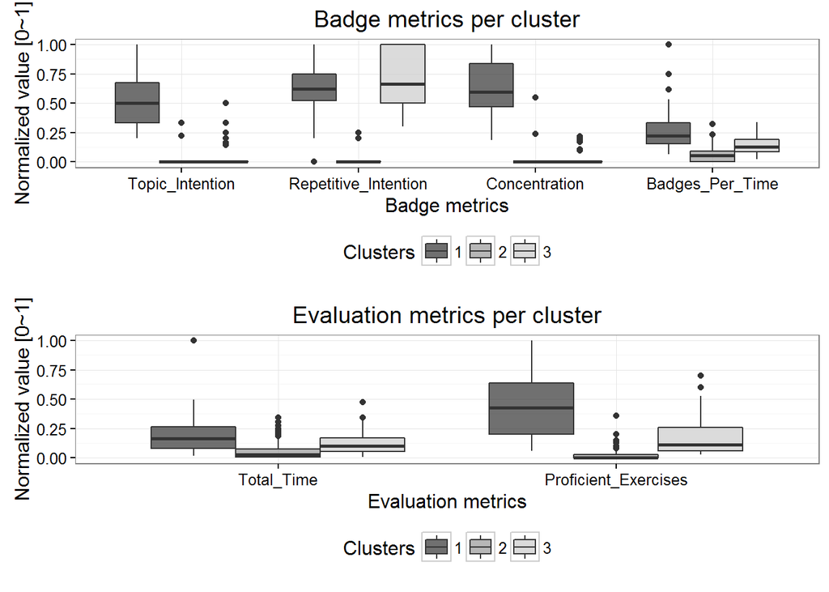

```r
p_badge_metrics <- ggplot(data = subset(meltDifferentStudents, Indicator %in% badge.metrics))  +
    geom_boxplot(aes(x=Indicator, y = value, fill = factor(Cluster_TwoSteps)), width = 1, alpha= .7) + theme_bw() + theme(legend.position = "bottom") +
    labs(x = "Badge metrics", y = "Normalized value [0~1]", title = "Badge metrics per cluster") + scale_fill_grey("Clusters")

p_evaluation_fields <- ggplot(data = subset(meltDifferentStudents, Indicator %in% evaluation.metrics))  +
    geom_boxplot(aes(x=Indicator, y = value, fill = factor(Cluster_TwoSteps)), width = 1, alpha= .7) + theme_bw() + theme(legend.position = "bottom") +
    labs(x = "Evaluation metrics", y = "Normalized value [0~1]", title = "Evaluation metrics per cluster") + scale_fill_grey("Clusters")

# create a grid with the two boxplots
grid.newpage()
pushViewport(viewport(layout = grid.layout(2, 1, heights = unit(c(5, 5), "null"))))
print(p_badge_metrics, vp = viewport(layout.pos.row = 1, layout.pos.col = 1))
print(p_evaluation_fields, vp = viewport(layout.pos.row = 2, layout.pos.col = 1))
```

Finally, make a parallel coordinates visualization for the badge metrics facetted by cluster

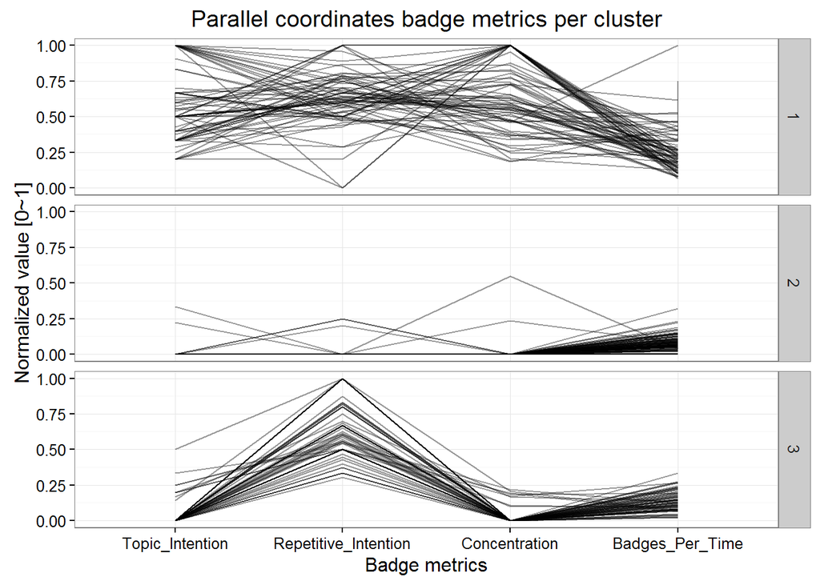

```r
p_parallel <- ggplot(aes(y = value, x = Indicator, group = User_id), data = subset(meltDifferentStudents, Indicator %in% c(badge.metrics, "User_id"))) + geom_line(alpha = .4) +
    facet_grid(Cluster_TwoSteps ~ .) + theme_bw() + labs(x = "Badge metrics", y = "Normalized value [0~1]", title = "Parallel coordinates badge metrics per cluster")
print(p_parallel)
```